# Homework 5

## **Due Date:** 2024-11-20 at 8:30 AM PT

**Name:** JJ Gluckman

## Preparation

1. We’re using the same [data file](https://github.com/gabehassler/PRGS-Intro-to-ML-2024/blob/main/data/processed/svi_covid.csv) from GitHub as the last assignment. If should be in the *data/processed* folder.

The below section was generated by the GitHub chat agent after several hours of trying to get Tensorflow working on my RAND laptop.

```r
Sys.setenv(RETICULATE_PYTHON = "C:/r-tf/Scripts/python.exe")
#logfile <- "submit.log"
#sink(logfile, append = FALSE, split = TRUE)
rm(list=ls())

if(Sys.getenv("RETICULATE_PYTHON") == "") {
  Sys.setenv(RETICULATE_PYTHON = "C:/Users/jgluckman/AppData/Local/r-reticulate/r-reticulate/pyenv/pyenv-win/versions/3.11.9/python.exe")
} else {
   #cat("Using RETICULATE_PYTHON=", Sys.getenv("RETICULATE_PYTHON"), "\n")
  }
```

```r
pacman::p_load(tidyverse, neuralnet, keras3, reticulate, tensorflow)
py_path <- Sys.getenv("RETICULATE_PYTHON")
if(py_path != "") {
  use_python(py_path, required = TRUE)
 } else {
   use_python("C:\\Users\\jgluckman\\AppData\\Local\\r-reticulate\\r-reticulate\\pyenv\\pyenv-win\\versions\\3.11.9\\python.exe", required=TRUE)
}
setwd("C:\\Users\\jgluckman\\OneDrive - RAND Corporation\\Desktop\\Machine Learning\\PRGS-Intro-to-ML-2025\\")
data <- read.csv("data\\processed\\svi_covid.csv")
```

## Homework - Neural Newtorks

1. Use a simple neural network to predict the number of per-capita COVID-19 deaths in each county in the US using the SVI variables. The outcome variable is `total_deaths_per_100k` and the predictor variables are `EP_POV150, EP_UNEMP, EP_HBURD, EP_NOHSDP, EP_UNINSUR, EP_AGE65, EP_AGE17, EP_DISABL, EP_SNGPNT, EP_LIMENG, EP_MINRTY, EP_MUNIT, EP_MOBILE, EP_CROWD, EP_NOVEH, EP_GROUPQ, EP_NOINT`. The neural network should have one hidden layer with 10 nodes and use the ReLU activation function. Plot the predicted values against the true values. What is the mean squared error of the predictions in the test set?

```r
keep <- c("total_deaths_per_100k", "EP_POV150", "EP_UNEMP", "EP_HBURD", "EP_NOHSDP", "EP_UNINSUR", "EP_AGE65", "EP_AGE17", "EP_DISABL", "EP_SNGPNT", "EP_LIMENG", "EP_MINRTY", "EP_MUNIT", "EP_MOBILE", "EP_CROWD", "EP_NOVEH", "EP_GROUPQ", "EP_NOINT")
data <- data[,keep]
train.perc <- 0.8
train.size <- round(train.perc*nrow(data))
test.size <- nrow(data) - train.size
assigns <- sample(0:1, nrow(data), prob = c(train.perc, (1-train.perc)), replace = TRUE)
train.df <- data[assigns == 0,]
test.df <- data[assigns == 1,]
```

Additional Chat fix for Python package errors

```r
if(!"keras" %in% loadedNamespaces()) {
   tryCatch(library(keras), error = function(e) print(paste("Warning: could not load keras: ", conditionMessage(e), "\n")))
 }
```

```
[1] "Warning: could not load keras:  there is no package called 'keras' \n"
```

```r
if(!"tensorflow" %in% loadedNamespaces()) {
   tryCatch(library(tensorflow), error = function(e) print(paste("Warning: could not load tensorflow: ", conditionMessage(e), "\n")))
 }
 if(!exists("keras_model_sequential")) {
   if(exists("keras_model_sequential", where = asNamespace("keras"), inherits = FALSE)) {
     assign("keras_model_sequential", get("keras_model_sequential", envir = asNamespace("keras")), envir = .GlobalEnv)
   }
 }
```

I had to consult the Chat for advice on how to clean the data to fit into the neural net, but the actual implementation has been modified by me

```r
factors <- names(train.df)[2:ncol(train.df)]
train.x <- train.df[,factors]
test.x <- test.df[,factors]
train.y <- c(train.df$total_deaths_per_100k)
test.y <- c(test.df$total_deaths_per_100k)

mean.list <- sapply(train.x, mean)
sds <- sapply(train.x, sd)
train.xs <- scale(train.x, center = mean.list, scale = sds)
test.xs <- scale(test.x, center = mean.list, scale = sds)
```

Code continued, input structure suggested by Chat but designed and implemented by me

```r
model.a <- keras_model_sequential()
model.a %>%
layer_dense(units = 10, activation = "relu") %>%
layer_dense(units = 1)
model.a %>% compile(optimizer = "adam", loss = "mse")
model.a %>% fit(x = train.xs, y = train.y, epochs = 100, batch_size = 32, validation_split = 0.2, verbose = 0)
```

Prediction segment also inspired by Chat but again designed by me

```r
preds <- model.a$predict(test.xs)
```

```
 1/21 ━━━━━━━━━━━━━━━━━━━━ 0s 45ms/step
21/21 ━━━━━━━━━━━━━━━━━━━━ 0s 2ms/step
```

```r
mse <- sum((preds-test.y)^2)/length(preds)
print(mse)
```

```
[1] 34460.37
```

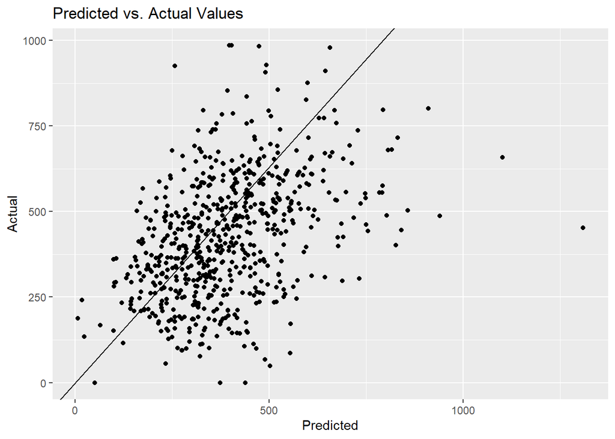

```r
slope <- mean(test.y/preds)
ggplot() +
geom_point(aes(x = preds, y = test.y)) +
geom_abline(slope = slope) +
labs(title = "Predicted vs. Actual Values", x = "Predicted", y = "Actual")
```

2. Repeat the analysis from the previous question, but this time use a more complicated neural network with more hidden layers and/or more nodes in the hidden layers. You should experiment with different architectures and activation functions to see what works best. Plot the predicted values against the true values. What is the mean squared error of the predictions in the test set?

```r
model.more.layers <- keras_model_sequential()
model.more.layers %>% layer_dense(units = 10, activation = "relu") %>% layer_dense(units = 10, activation = "relu") %>%  layer_dense(units = 10, activation = "relu") %>%  layer_dense(1)
model.more.layers %>% compile(optimizer = "adam", loss = "mse")
model.more.layers %>% fit(x = train.xs, y = train.y, epochs = 100, batch_size = 32, validation_split = 0.2, verbose = 0)

preds.b <- model.more.layers$predict(test.xs)
```

```
 1/21 ━━━━━━━━━━━━━━━━━━━━ 0s 48ms/step
21/21 ━━━━━━━━━━━━━━━━━━━━ 0s 2ms/step
```

```r
mse.b <- sum((preds.b-test.y)^2)/length(preds.b)
print(mse.b)
```

```
[1] 19786.47
```

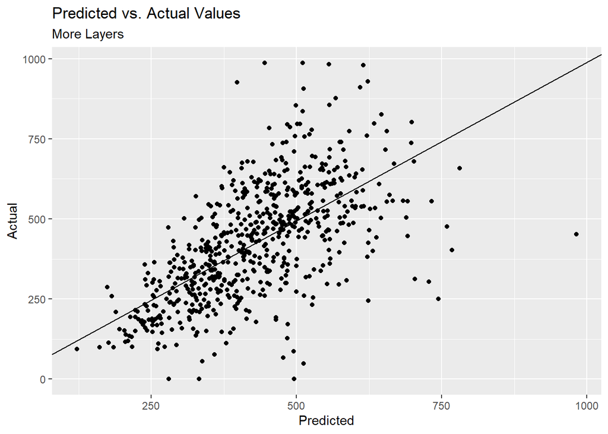

```r
slope.b <- mean(test.y/preds.b)
ggplot() +
geom_point(aes(x = preds.b, y = test.y)) +
geom_abline(slope = slope.b) +
labs(title = "Predicted vs. Actual Values", subtitle = "More Layers", x = "Predicted", y = "Actual")
```

```r
model.more.nodes <- keras_model_sequential()
model.more.nodes %>% layer_dense(units = 15, activation = "relu") %>% layer_dense(1)
model.more.nodes %>% compile(optimizer = "adam", loss = "mse")
model.more.nodes %>% fit(x = train.xs, y = train.y, epochs = 100, batch_size = 32, validation_split = 0.2, verbose = 0)

preds.c <- model.more.nodes$predict(test.xs)
```

```
 1/21 ━━━━━━━━━━━━━━━━━━━━ 0s 33ms/step
21/21 ━━━━━━━━━━━━━━━━━━━━ 0s 3ms/step
```

```r
mse.c <- sum((preds.c-test.y)^2)/length(preds.c)
print(mse.c)
```

```
[1] 29888.6
```

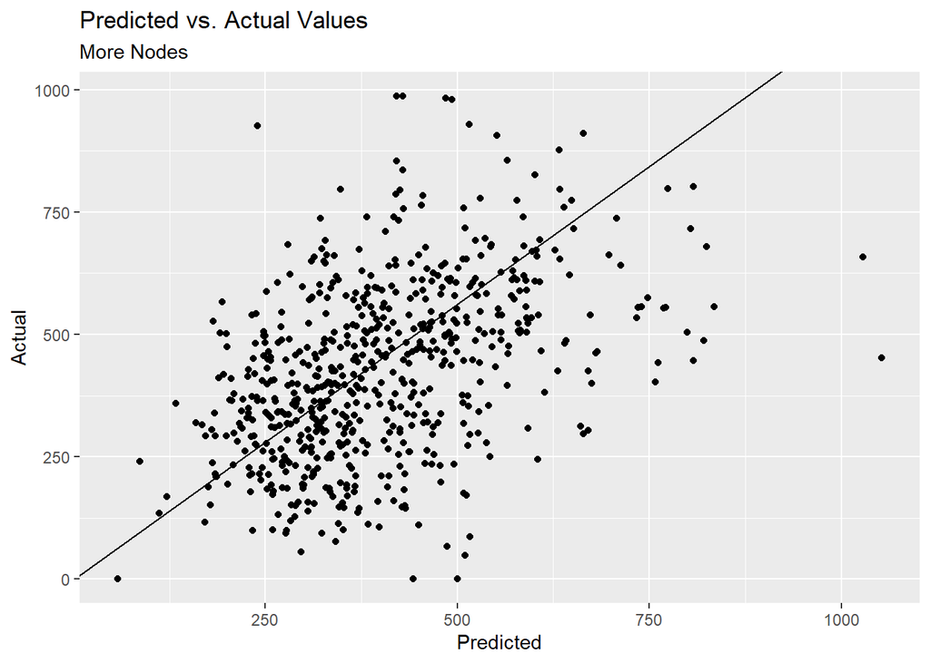

```r
slope.c <- mean(test.y/preds.c)
ggplot() +
geom_point(aes(x = preds.c, y = test.y)) +
geom_abline(slope = slope.c) +
labs(title = "Predicted vs. Actual Values", subtitle = "More Nodes", x = "Predicted", y = "Actual")
```

```r
model.softmax <- keras_model_sequential()
model.softmax %>% layer_dense(units = 10, activation = "softmax") %>% layer_dense(1)
model.softmax %>% compile(optimizer = "adam", loss = "mse")
model.softmax %>% fit(x = train.xs, y = train.y, epochs = 100, batch_size = 32, validation_split = 0.2, verbose = 0)

preds.d <- model.softmax$predict(test.xs)
```

```
 1/21 ━━━━━━━━━━━━━━━━━━━━ 0s 34ms/step
21/21 ━━━━━━━━━━━━━━━━━━━━ 0s 2ms/step
```

```r
mse.d <- sum((preds.d-test.y)^2)/length(preds.d)
print(mse.d)
```

```
[1] 201205.6
```

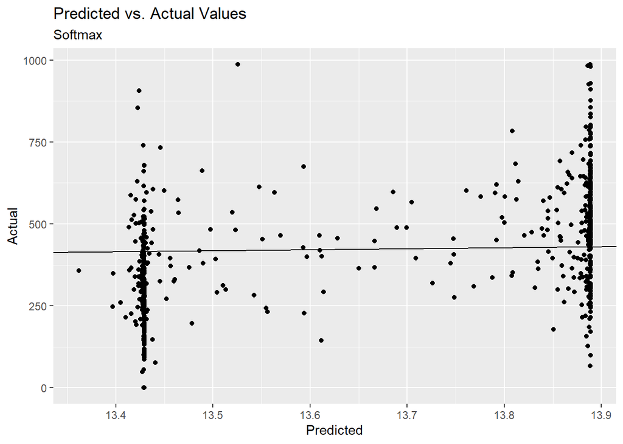

```r
slope.d <- mean(test.y/preds.d)
ggplot() +
geom_point(aes(x = preds.d, y = test.y)) +
geom_abline(slope = slope.d) +
labs(title = "Predicted vs. Actual Values", subtitle = "Softmax", x = "Predicted", y = "Actual")
```

3. Compare the predictions of the neural network in Question 2 to the predictions of the regression tree from the previous assignment. Which model would you use to predict the number of per-capita COVID-19 deaths? Why?